# Biostat 203B Homework 5

Due Mar 22 @ 11:59PM

Author

Yuhui Wang, UID: 606332401

## Predicting ICU duration

Using the ICU cohort `mimiciv_icu_cohort.rds` you built in Homework 4, develop at least three machine learning approaches (logistic regression with enet regularization, random forest, boosting, SVM, MLP, etc) plus a model stacking approach for predicting whether a patient’s ICU stay will be longer than 2 days. You should use the `los_long` variable as the outcome. You algorithms can use patient demographic information (gender, age at ICU `intime`, marital status, race), ICU admission information (first care unit), the last lab measurements before the ICU stay, and first vital measurements during ICU stay as features. You are welcome to use any feature engineering techniques you think are appropriate; but make sure to not use features that are not available at an ICU stay’s `intime`. For instance, `last_careunit` cannot be used in your algorithms.

```r
library(bigrquery)
library(dbplyr)
library(DBI)
library(gt)
library(gtsummary)
library(tidyverse)
library(tidymodels)
library(styler)
library(glmnet)
library(GGally)
library(ranger)
library(kernlab)
library(keras)
library(stacks)
library(vip)
library(rpart)
library(tensorflow)
```

# 1. Data preprocessing and feature engineering.

Ingest the data

```r
mimic_icu_cohort <- readRDS("./mimic_icu_cohort.rds")
```

Feature engineering

```r
mimic_icu_cohort <- mimic_icu_cohort %>%
  select(-c(
    last_careunit,
    outtime, dischtime, deathtime, discharge_location,
    edouttime, hospital_expire_flag, los, dod,
    admit_provider_id, intime, admittime,
    edregtime, anchor_year_group
  )) %>%
  mutate(los_long = factor(ifelse(los_long, "long", "short"))) %>%
  mutate(across(where(is.character), as.factor))
```

Summary of data

```r
tbl_summary(mimic_icu_cohort, by = los_long)
```

| **Characteristic** | **long**, N = 35,131<sup>1</sup> | **short**, N = 38,050<sup>1</sup> |
| --- | --- | --- |
| subject_id | 14,995,832 (12,498,337, 17,496,102) | 15,002,798 (12,488,949, 17,523,219) |
| hadm_id | 24,995,222 (22,499,999, 27,473,223) | 24,949,943 (22,469,194, 27,466,877) |
| stay_id | 34,960,130 (32,470,375, 37,471,693) | 35,026,375 (32,509,262, 37,504,248) |
| first_careunit |  |  |
| Cardiac Vascular Intensive Care Unit (CVICU) | 5,755 (16%) | 5,827 (15%) |
| Medical Intensive Care Unit (MICU) | 7,116 (20%) | 8,782 (23%) |
| Medical/Surgical Intensive Care Unit (MICU/SICU) | 5,586 (16%) | 7,147 (19%) |
| Surgical Intensive Care Unit (SICU) | 5,507 (16%) | 5,654 (15%) |
| Other | 11,167 (32%) | 10,640 (28%) |
| admission_type |  |  |
| EW EMER. | 17,937 (51%) | 20,735 (54%) |
| OBSERVATION ADMIT | 4,645 (13%) | 4,329 (11%) |
| SURGICAL SAME DAY ADMISSION | 3,033 (8.6%) | 4,340 (11%) |
| URGENT | 6,959 (20%) | 5,494 (14%) |
| Other | 2,557 (7.3%) | 3,152 (8.3%) |
| admission_location |  |  |
| EMERGENCY ROOM | 16,279 (46%) | 19,602 (52%) |
| PHYSICIAN REFERRAL | 7,412 (21%) | 8,986 (24%) |
| TRANSFER FROM HOSPITAL | 8,959 (26%) | 6,839 (18%) |
| WALK-IN/SELF REFERRAL | 791 (2.3%) | 876 (2.3%) |
| Other | 1,690 (4.8%) | 1,747 (4.6%) |
| insurance |  |  |
| Medicaid | 2,468 (7.0%) | 3,060 (8.0%) |
| Medicare | 16,602 (47%) | 16,489 (43%) |
| Other | 16,061 (46%) | 18,501 (49%) |
| language |  |  |
| ? | 3,751 (11%) | 3,692 (9.7%) |
| ENGLISH | 31,380 (89%) | 34,358 (90%) |
| marital_status |  |  |
| DIVORCED | 2,561 (7.9%) | 2,843 (8.0%) |
| MARRIED | 15,784 (49%) | 16,984 (48%) |
| SINGLE | 9,683 (30%) | 11,175 (31%) |
| WIDOWED | 4,339 (13%) | 4,699 (13%) |
| Unknown | 2,764 | 2,349 |
| race |  |  |
| Other | 5,596 (16%) | 5,160 (14%) |
| ASIAN | 1,007 (2.9%) | 1,148 (3.0%) |
| BLACK | 3,649 (10%) | 4,311 (11%) |
| HISPANIC | 1,249 (3.6%) | 1,492 (3.9%) |
| WHITE | 23,630 (67%) | 25,939 (68%) |
| gender |  |  |
| F | 15,349 (44%) | 17,014 (45%) |
| M | 19,782 (56%) | 21,036 (55%) |
| anchor_age | 66 (54, 76) | 64 (52, 76) |
| anchor_year | 2,152 (2,132, 2,172) | 2,152 (2,132, 2,172) |
| age_intime | 67 (56, 78) | 65 (53, 77) |
| Creatinine | 1.00 (0.80, 1.60) | 1.00 (0.80, 1.40) |
| Unknown | 3,171 | 2,599 |
| White Blood Cells | 9.7 (7.0, 13.8) | 9.0 (6.6, 12.6) |
| Unknown | 2,822 | 2,272 |
| Glucose | 122 (100, 159) | 118 (98, 153) |
| Unknown | 4,817 | 4,282 |
| Hematocrit | 35 (29, 40) | 36 (30, 40) |
| Unknown | 2,781 | 2,236 |
| Bicarbonate | 24.0 (21.0, 27.0) | 25.0 (22.0, 27.0) |
| Unknown | 4,780 | 4,270 |
| Potassium | 4.20 (3.80, 4.70) | 4.20 (3.80, 4.60) |
| Unknown | 4,712 | 4,189 |
| Chloride | 102 (98, 105) | 102 (98, 105) |
| Unknown | 4,708 | 4,175 |
| Sodium | 138.0 (135.0, 141.0) | 139.0 (136.0, 141.0) |
| Unknown | 4,698 | 4,174 |
| Respiratory Rate | 19.0 (15.0, 23.0) | 18.0 (15.0, 22.0) |
| Unknown | 10 | 81 |
| Heart Rate | 88 (76, 103) | 85 (74, 99) |
| Unknown | 1 | 17 |
| Non Invasive Blood Pressure systolic | 120 (104, 138) | 123 (108, 140) |
| Unknown | 241 | 709 |
| Non Invasive Blood Pressure diastolic | 66 (56, 79) | 68 (58, 80) |
| Unknown | 244 | 709 |
| Temperature Fahrenheit | 98.20 (97.60, 98.80) | 98.10 (97.60, 98.60) |
| Unknown | 170 | 1,079 |

<sup>1</sup> Median (IQR); n (%)

# 2. Partition data into 50% training set and 50% test set.

Stratify partitioning according to `los_long`. For grading purpose, sort the data by `subject_id`, `hadm_id`, and `stay_id` and use the seed `203` for the initial data split. Below is the sample code.

```r
set.seed(203)

# sort
mimiciv_icu_cohort <- mimic_icu_cohort |>
  arrange(subject_id, hadm_id, stay_id) |>
  select(-c(subject_id, hadm_id, stay_id))

data_split <- initial_split(
  mimiciv_icu_cohort,
  # stratify by los_long
  strata = "los_long",
  prop = 0.5
)

data_split
```

```
<Training/Testing/Total>
<36590/36591/73181>
```

```r
# training set
mimic_other <- training(data_split)
dim(mimic_other)
```

```
[1] 36590    25
```

```r
# test set
mimic_test <- testing(data_split)
dim(mimic_test)
```

```
[1] 36591    25
```

Recipe

```r
norm_recipe <-
  recipe(
    los_long ~ .,
    data = mimic_other
  ) %>%
  step_impute_mean(all_numeric(), -all_outcomes()) %>%
  # Impute categorical variables using KNN or another appropriate method
  step_impute_knn(all_nominal(), -all_outcomes()) %>%
  # Convert all nominal variables to dummy variables, excluding the outcome
  step_dummy(all_nominal(), -all_outcomes()) %>%
  # Remove zero variance predictors
  step_zv(all_numeric_predictors()) %>%
  # Normalize all numeric predictors
  step_normalize(all_numeric_predictors())

norm_recipe
```

```
── Recipe ──────────────────────────────────────────────────────────────────────
```

```
── Inputs
```

```
Number of variables by role
```

```
outcome:    1
predictor: 24
```

```
── Operations
```

```
• Mean imputation for: all_numeric() and -all_outcomes()
```

```
• K-nearest neighbor imputation for: all_nominal() and -all_outcomes()
```

```
• Dummy variables from: all_nominal() and -all_outcomes()
```

```
• Zero variance filter on: all_numeric_predictors()
```

```
• Centering and scaling for: all_numeric_predictors()
```

# 3. Train and tune the models using the training set.

Set cross-validation

```r
set.seed(203)
folds <- vfold_cv(mimic_other, v = 5)
folds
```

```
#  5-fold cross-validation
# A tibble: 5 × 2
  splits               id
  <list>               <chr>
1 <split [29272/7318]> Fold1
2 <split [29272/7318]> Fold2
3 <split [29272/7318]> Fold3
4 <split [29272/7318]> Fold4
5 <split [29272/7318]> Fold5
```

```r
enet_mod <-
  logistic_reg(
    penalty = tune(),
    mixture = tune(),
    mode = "classification"
  ) %>%
  set_engine("glmnet")
enet_mod
```

```
Logistic Regression Model Specification (classification)

Main Arguments:
  penalty = tune()
  mixture = tune()

Computational engine: glmnet
```

Workflow

```r
lr_wf <-
  workflow() %>%
  add_recipe(norm_recipe) %>%
  add_model(enet_mod)
lr_wf
```

```
══ Workflow ════════════════════════════════════════════════════════════════════
Preprocessor: Recipe
Model: logistic_reg()

── Preprocessor ────────────────────────────────────────────────────────────────
5 Recipe Steps

• step_impute_mean()
• step_impute_knn()
• step_dummy()
• step_zv()
• step_normalize()

── Model ───────────────────────────────────────────────────────────────────────
Logistic Regression Model Specification (classification)

Main Arguments:
  penalty = tune()
  mixture = tune()

Computational engine: glmnet
```

Tuning grid

```r
param_grid_lr <- grid_regular(
  penalty(range = c(-6, 3)),
  mixture(),
  levels = c(100, 5)
)
param_grid_lr
```

```
# A tibble: 500 × 2
      penalty mixture
        <dbl>   <dbl>
 1 0.000001         0
 2 0.00000123       0
 3 0.00000152       0
 4 0.00000187       0
 5 0.00000231       0
 6 0.00000285       0
 7 0.00000351       0
 8 0.00000433       0
 9 0.00000534       0
10 0.00000658       0
# ℹ 490 more rows
```

Fit cross-validation

```r
enet_fit <-
  lr_wf %>%
  tune_grid(
    resamples = folds,
    grid = param_grid_lr,
    metrics = metric_set(roc_auc, accuracy),
    control = control_stack_grid()
  )
```

```
ℹ The workflow being saved contains a recipe, which is 5.38 Mb in ℹ memory. If
this was not intentional, please set the control setting ℹ `save_workflow =
FALSE`.
```

```r
enet_fit
```

```
# Tuning results
# 5-fold cross-validation
# A tibble: 5 × 5
  splits               id    .metrics             .notes           .predictions
  <list>               <chr> <list>               <list>           <list>
1 <split [29272/7318]> Fold1 <tibble [1,000 × 6]> <tibble [0 × 3]> <tibble>
2 <split [29272/7318]> Fold2 <tibble [1,000 × 6]> <tibble [0 × 3]> <tibble>
3 <split [29272/7318]> Fold3 <tibble [1,000 × 6]> <tibble [0 × 3]> <tibble>
4 <split [29272/7318]> Fold4 <tibble [1,000 × 6]> <tibble [0 × 3]> <tibble>
5 <split [29272/7318]> Fold5 <tibble [1,000 × 6]> <tibble [0 × 3]> <tibble>
```

Visualize CV results

```
# A tibble: 1,000 × 8
      penalty mixture .metric  .estimator  mean     n std_err
        <dbl>   <dbl> <chr>    <chr>      <dbl> <int>   <dbl>
 1 0.000001         0 accuracy binary     0.576     5 0.00215
 2 0.000001         0 roc_auc  binary     0.608     5 0.00159
 3 0.00000123       0 accuracy binary     0.576     5 0.00215
 4 0.00000123       0 roc_auc  binary     0.608     5 0.00159
 5 0.00000152       0 accuracy binary     0.576     5 0.00215
 6 0.00000152       0 roc_auc  binary     0.608     5 0.00159
 7 0.00000187       0 accuracy binary     0.576     5 0.00215
 8 0.00000187       0 roc_auc  binary     0.608     5 0.00159
 9 0.00000231       0 accuracy binary     0.576     5 0.00215
10 0.00000231       0 roc_auc  binary     0.608     5 0.00159
   .config
   <chr>
 1 Preprocessor1_Model001
 2 Preprocessor1_Model001
 3 Preprocessor1_Model002
 4 Preprocessor1_Model002
 5 Preprocessor1_Model003
 6 Preprocessor1_Model003
 7 Preprocessor1_Model004
 8 Preprocessor1_Model004
 9 Preprocessor1_Model005
10 Preprocessor1_Model005
# ℹ 990 more rows
```

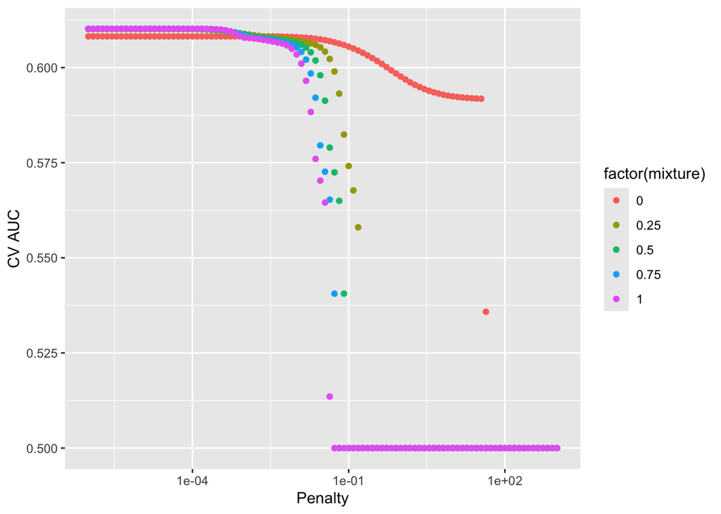

```r
enet_fit |>
  # aggregate metrics from K folds
  collect_metrics() |>
  print(width = Inf) |>
  filter(.metric == "roc_auc") |>
  ggplot(mapping = aes(x = penalty, y = mean, color = factor(mixture))) +
  geom_point() +
  labs(x = "Penalty", y = "CV AUC") +
  scale_x_log10()
```

Show the top 5 models

```r
enet_fit |>
  show_best("roc_auc")
```

```
# A tibble: 5 × 8
     penalty mixture .metric .estimator  mean     n std_err .config
       <dbl>   <dbl> <chr>   <chr>      <dbl> <int>   <dbl> <chr>
1 0.000152      1    roc_auc binary     0.610     5 0.00189 Preprocessor1_Model…
2 0.000123      0.75 roc_auc binary     0.610     5 0.00187 Preprocessor1_Model…
3 0.0000811     0.5  roc_auc binary     0.610     5 0.00187 Preprocessor1_Model…
4 0.000001      0.5  roc_auc binary     0.610     5 0.00187 Preprocessor1_Model…
5 0.00000123    0.5  roc_auc binary     0.610     5 0.00187 Preprocessor1_Model…
```

Select the best model

```r
best_logit <- enet_fit |>
  select_best("roc_auc")
best_logit
```

```
# A tibble: 1 × 3
   penalty mixture .config
     <dbl>   <dbl> <chr>
1 0.000152       1 Preprocessor1_Model425
```

## Random forest

```r
rf_mod <-
  rand_forest(
    mode = "classification",
    # Number of predictors randomly sampled in each split
    mtry = tune(),
    # Number of trees in ensemble
    trees = tune()
  ) %>%
  set_engine("ranger", importance = "impurity")
rf_mod
```

```
Random Forest Model Specification (classification)

Main Arguments:
  mtry = tune()
  trees = tune()

Engine-Specific Arguments:
  importance = impurity

Computational engine: ranger
```

Workflow

```r
rf_wf <- workflow() %>%
  add_recipe(norm_recipe) %>%
  add_model(rf_mod)
rf_wf
```

```
══ Workflow ════════════════════════════════════════════════════════════════════
Preprocessor: Recipe
Model: rand_forest()

── Preprocessor ────────────────────────────────────────────────────────────────
5 Recipe Steps

• step_impute_mean()
• step_impute_knn()
• step_dummy()
• step_zv()
• step_normalize()

── Model ───────────────────────────────────────────────────────────────────────
Random Forest Model Specification (classification)

Main Arguments:
  mtry = tune()
  trees = tune()

Engine-Specific Arguments:
  importance = impurity

Computational engine: ranger
```

Tuning grid

```r
param_grid_rf <- grid_regular(
  trees(range = c(500L, 700L)),
  mtry(range = c(2L, 7L)),
  levels = c(3, 5)
)
param_grid_rf
```

```
# A tibble: 15 × 2
   trees  mtry
   <int> <int>
 1   500     2
 2   600     2
 3   700     2
 4   500     3
 5   600     3
 6   700     3
 7   500     4
 8   600     4
 9   700     4
10   500     5
11   600     5
12   700     5
13   500     7
14   600     7
15   700     7
```

Fit cross-validation

```r
rf_fit <- rf_wf %>%
  tune_grid(
    resamples = folds,
    grid = param_grid_rf,
    metrics = metric_set(roc_auc, accuracy),
    control = control_stack_grid()
  )
```

```
ℹ The workflow being saved contains a recipe, which is 5.38 Mb in ℹ memory. If
this was not intentional, please set the control setting ℹ `save_workflow =
FALSE`.
```

```r
rf_fit
```

```
# Tuning results
# 5-fold cross-validation
# A tibble: 5 × 5
  splits               id    .metrics          .notes           .predictions
  <list>               <chr> <list>            <list>           <list>
1 <split [29272/7318]> Fold1 <tibble [30 × 6]> <tibble [0 × 3]> <tibble>
2 <split [29272/7318]> Fold2 <tibble [30 × 6]> <tibble [0 × 3]> <tibble>
3 <split [29272/7318]> Fold3 <tibble [30 × 6]> <tibble [0 × 3]> <tibble>
4 <split [29272/7318]> Fold4 <tibble [30 × 6]> <tibble [0 × 3]> <tibble>
5 <split [29272/7318]> Fold5 <tibble [30 × 6]> <tibble [0 × 3]> <tibble>
```

Visualize CV results

```
# A tibble: 30 × 8
    mtry trees .metric  .estimator  mean     n std_err .config
   <int> <int> <chr>    <chr>      <dbl> <int>   <dbl> <chr>
 1     2   500 accuracy binary     0.602     5 0.00246 Preprocessor1_Model01
 2     2   500 roc_auc  binary     0.642     5 0.00196 Preprocessor1_Model01
 3     2   600 accuracy binary     0.603     5 0.00161 Preprocessor1_Model02
 4     2   600 roc_auc  binary     0.643     5 0.00180 Preprocessor1_Model02
 5     2   700 accuracy binary     0.603     5 0.00147 Preprocessor1_Model03
 6     2   700 roc_auc  binary     0.644     5 0.00160 Preprocessor1_Model03
 7     3   500 accuracy binary     0.604     5 0.00179 Preprocessor1_Model04
 8     3   500 roc_auc  binary     0.644     5 0.00130 Preprocessor1_Model04
 9     3   600 accuracy binary     0.602     5 0.00227 Preprocessor1_Model05
10     3   600 roc_auc  binary     0.645     5 0.00182 Preprocessor1_Model05
# ℹ 20 more rows
```

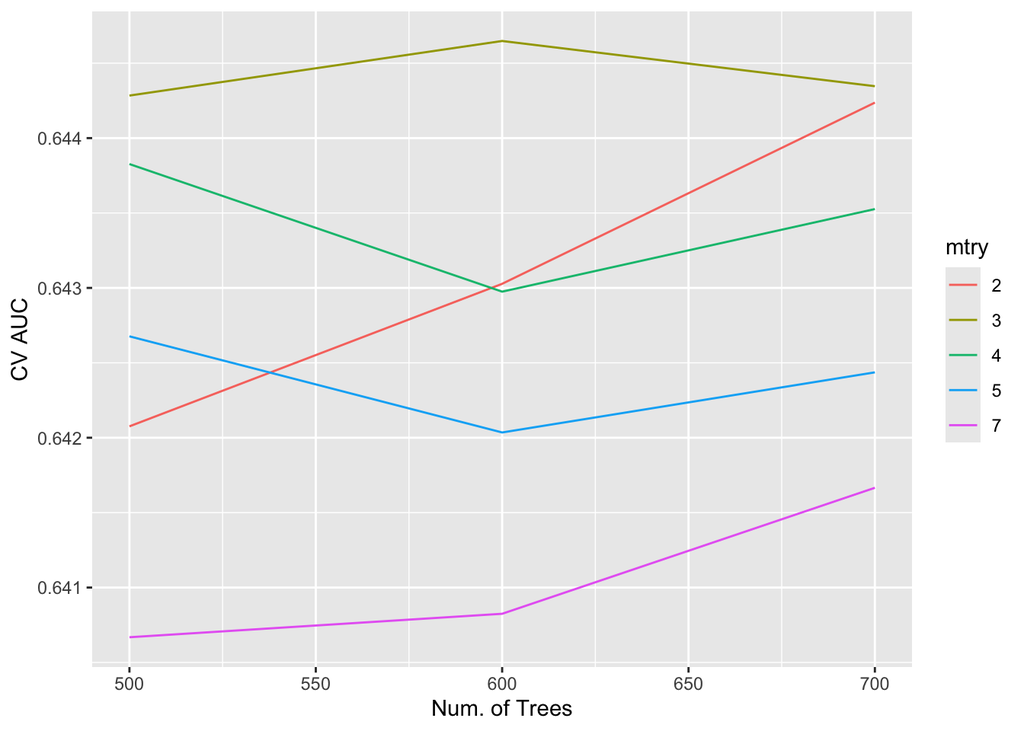

```r
rf_fit %>%
  collect_metrics() %>%
  print(width = Inf) %>%
  filter(.metric == "roc_auc") %>%
  mutate(mtry = as.factor(mtry)) %>%
  ggplot(mapping = aes(x = trees, y = mean, color = mtry)) +
  # geom_point() +
  geom_line() +
  labs(x = "Num. of Trees", y = "CV AUC")
```

Show the top 5 models

```r
rf_fit %>%
  show_best("roc_auc")
```

```
# A tibble: 5 × 8
   mtry trees .metric .estimator  mean     n std_err .config
  <int> <int> <chr>   <chr>      <dbl> <int>   <dbl> <chr>
1     3   600 roc_auc binary     0.645     5 0.00182 Preprocessor1_Model05
2     3   700 roc_auc binary     0.644     5 0.00173 Preprocessor1_Model06
3     3   500 roc_auc binary     0.644     5 0.00130 Preprocessor1_Model04
4     2   700 roc_auc binary     0.644     5 0.00160 Preprocessor1_Model03
5     4   500 roc_auc binary     0.644     5 0.00153 Preprocessor1_Model07
```

Select the best model

```r
best_rf <- rf_fit %>%
  select_best("roc_auc")
best_rf
```

```
# A tibble: 1 × 3
   mtry trees .config
  <int> <int> <chr>
1     3   600 Preprocessor1_Model05
```

## Boosting

```r
gb_mod <-
  boost_tree(
    mode = "classification",
    trees = 1000,
    tree_depth = tune(),
    learn_rate = tune()
  ) %>%
  set_engine("xgboost")
gb_mod
```

```
Boosted Tree Model Specification (classification)

Main Arguments:
  trees = 1000
  tree_depth = tune()
  learn_rate = tune()

Computational engine: xgboost
```

Workflow

```r
gb_wf <- workflow() %>%
  add_recipe(norm_recipe) %>%
  add_model(gb_mod)
gb_wf
```

```
══ Workflow ════════════════════════════════════════════════════════════════════
Preprocessor: Recipe
Model: boost_tree()

── Preprocessor ────────────────────────────────────────────────────────────────
5 Recipe Steps

• step_impute_mean()
• step_impute_knn()
• step_dummy()
• step_zv()
• step_normalize()

── Model ───────────────────────────────────────────────────────────────────────
Boosted Tree Model Specification (classification)

Main Arguments:
  trees = 1000
  tree_depth = tune()
  learn_rate = tune()

Computational engine: xgboost
```

Tuning grid

```r
param_grid_gb <- grid_regular(
  tree_depth(range = c(1L, 3L)),
  learn_rate(range = c(-5, 2), trans = log10_trans()),
  levels = c(3, 10)
)
param_grid_gb
```

```
# A tibble: 30 × 2
   tree_depth learn_rate
        <int>      <dbl>
 1          1  0.00001
 2          2  0.00001
 3          3  0.00001
 4          1  0.0000599
 5          2  0.0000599
 6          3  0.0000599
 7          1  0.000359
 8          2  0.000359
 9          3  0.000359
10          1  0.00215
# ℹ 20 more rows
```

Fit cross-validation

```r
gb_fit <- gb_wf %>%
  tune_grid(
    resamples = folds,
    grid = param_grid_gb,
    metrics = metric_set(roc_auc, accuracy),
    control = control_stack_grid()
  )
```

```
ℹ The workflow being saved contains a recipe, which is 5.38 Mb in ℹ memory. If
this was not intentional, please set the control setting ℹ `save_workflow =
FALSE`.
```

```r
gb_fit
```

```
# Tuning results
# 5-fold cross-validation
# A tibble: 5 × 5
  splits               id    .metrics          .notes           .predictions
  <list>               <chr> <list>            <list>           <list>
1 <split [29272/7318]> Fold1 <tibble [60 × 6]> <tibble [0 × 3]> <tibble>
2 <split [29272/7318]> Fold2 <tibble [60 × 6]> <tibble [0 × 3]> <tibble>
3 <split [29272/7318]> Fold3 <tibble [60 × 6]> <tibble [0 × 3]> <tibble>
4 <split [29272/7318]> Fold4 <tibble [60 × 6]> <tibble [0 × 3]> <tibble>
5 <split [29272/7318]> Fold5 <tibble [60 × 6]> <tibble [0 × 3]> <tibble>
```

Visualize CV results

```
# A tibble: 60 × 8
   tree_depth learn_rate .metric  .estimator  mean     n std_err
        <int>      <dbl> <chr>    <chr>      <dbl> <int>   <dbl>
 1          1  0.00001   accuracy binary     0.547     5 0.00246
 2          1  0.00001   roc_auc  binary     0.536     5 0.00104
 3          2  0.00001   accuracy binary     0.554     5 0.00220
 4          2  0.00001   roc_auc  binary     0.555     5 0.00346
 5          3  0.00001   accuracy binary     0.554     5 0.00188
 6          3  0.00001   roc_auc  binary     0.571     5 0.00117
 7          1  0.0000599 accuracy binary     0.547     5 0.00246
 8          1  0.0000599 roc_auc  binary     0.544     5 0.00580
 9          2  0.0000599 accuracy binary     0.555     5 0.00199
10          2  0.0000599 roc_auc  binary     0.558     5 0.00518
   .config
   <chr>
 1 Preprocessor1_Model01
 2 Preprocessor1_Model01
 3 Preprocessor1_Model02
 4 Preprocessor1_Model02
 5 Preprocessor1_Model03
 6 Preprocessor1_Model03
 7 Preprocessor1_Model04
 8 Preprocessor1_Model04
 9 Preprocessor1_Model05
10 Preprocessor1_Model05
# ℹ 50 more rows
```

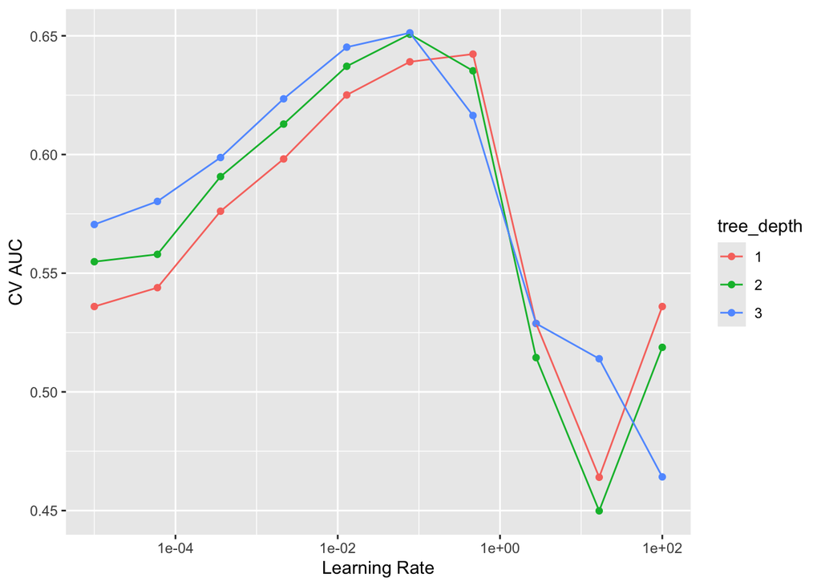

```r
gb_fit %>%
  collect_metrics() %>%
  print(width = Inf) %>%
  filter(.metric == "roc_auc") %>%
  mutate(tree_depth = as.factor(tree_depth)) %>%
  ggplot(mapping = aes(
    x = learn_rate,
    y = mean,
    color = tree_depth
  )) +
  geom_point() +
  geom_line() +
  labs(x = "Learning Rate", y = "CV AUC") +
  scale_x_log10()
```

Show the top 5 models

```r
gb_fit %>%
  show_best("roc_auc")
```

```
# A tibble: 5 × 8
  tree_depth learn_rate .metric .estimator  mean     n  std_err .config
       <int>      <dbl> <chr>   <chr>      <dbl> <int>    <dbl> <chr>
1          3     0.0774 roc_auc binary     0.651     5 0.00162  Preprocessor1_M…
2          2     0.0774 roc_auc binary     0.651     5 0.00156  Preprocessor1_M…
3          3     0.0129 roc_auc binary     0.645     5 0.000869 Preprocessor1_M…
4          1     0.464  roc_auc binary     0.642     5 0.00179  Preprocessor1_M…
5          1     0.0774 roc_auc binary     0.639     5 0.00141  Preprocessor1_M…
```

Select the best model

```r
best_gb <- gb_fit %>%
  select_best("roc_auc")
best_gb
```

```
# A tibble: 1 × 3
  tree_depth learn_rate .config
       <int>      <dbl> <chr>
1          3     0.0774 Preprocessor1_Model18
```

## SVM with radial kernel

Since SVM will take a much long time to run, we will not run it here. But the code is provided below.

```r
# svm_mod <-
#   svm_rbf(
#     mode = "classification",
#     cost = tune(),
#     rbf_sigma = tune()
#   ) %>%
#   set_engine("kernlab")
# svm_mod
```

Workflow

```r
# svm_wf <- workflow() %>%
#   add_recipe(norm_recipe) %>%
#   add_model(svm_mod)
# svm_wf
```

Tuning grid

```r
# param_grid <- grid_regular(
#   cost(range = c(-8, 5)),
#   rbf_sigma(range = c(-5, -3)),
#   levels = c(14, 5)
#   )
# param_grid
```

Fit cross-validation

```r
# svm_fit <- svm_wf %>%
#   tune_grid(
#     resamples = folds,
#     grid = param_grid,
#     metrics = metric_set(roc_auc, accuracy)
#     )
# svm_fit
```

## MLP

Since MLP will take a much long time to run, we will not run it here. But the code is provided below.

```r
# mlp_mod <-
#   mlp(
#     mode = "classification",
#     hidden_units = tune(),
#     dropout = tune(),
#     epochs = 50,
#   ) |>
#   set_engine("keras", verbose = 0)
# mlp_mod
```

Workflow

```r
# mlp_wf <- workflow() |>
#   add_recipe(norm_recipe) |>
#   add_model(mlp_mod)
# mlp_wf
```

Tuning grid

```r
# param_grid_mlp <- grid_regular(
#   hidden_units(range = c(1, 20)),
#   dropout(range = c(0, 0.6)),
#   levels = 5
#   )
# param_grid_mlp
```

Fit cross-validation

```r
# mlp_fit <- mlp_wf |>
#   tune_grid(
#     resamples = folds,
#     grid = param_grid_mlp,
#     metrics = metric_set(roc_auc, accuracy)
#     )
# mlp_fit
```

Visualize CV results

```r
# mlp_fit |>
#   collect_metrics() |>
#   print(width = Inf) |>
#   filter(.metric == "roc_auc") |>
# ggplot(mapping = aes(x = dropout, y = mean,
#                      color = factor(hidden_units))) +
#   geom_point() +
#   labs(x = "Dropout Rate", y = "CV AUC") +
#   scale_x_log10()
```

Show the top 5 models

```r
# mlp_fit |>
#   show_best("roc_auc")
```

Select the best model

```r
# best_mlp <- mlp_fit |>
#   select_best("roc_auc")
# best_mlp
```

## Stacking

As logistic regression has a comparable lower performance than random forest and boosting from my experiments, here we will not put it as an candidate in stacking model.

```r
model_st <-
  # initialize the stack
  stacks() |>
  # add candidate members
  # add_candidates(enet_fit) |>
  add_candidates(rf_fit) |>
  add_candidates(gb_fit) |>
  # determine how to combine their predictions
  blend_predictions(
    penalty = 10^(-6:2),
    metrics = c("roc_auc", "accuracy")
  ) |>
  # fit the candidates with nonzero stacking coefficients
  fit_members()
model_st
```

```
── A stacked ensemble model ─────────────────────────────────────


Out of 45 possible candidate members, the ensemble retained 14.

Penalty: 1e-04.

Mixture: 1.


The 10 highest weighted member classes are:
```

```
# A tibble: 10 × 3
   member                  type        weight
   <chr>                   <chr>        <dbl>
 1 .pred_short_gb_fit_1_18 boost_tree  1.46
 2 .pred_short_gb_fit_1_17 boost_tree  1.01
 3 .pred_short_rf_fit_1_05 rand_forest 0.935
 4 .pred_short_rf_fit_1_07 rand_forest 0.692
 5 .pred_short_rf_fit_1_04 rand_forest 0.635
 6 .pred_short_rf_fit_1_03 rand_forest 0.314
 7 .pred_short_gb_fit_1_19 boost_tree  0.255
 8 .pred_short_gb_fit_1_26 boost_tree  0.115
 9 .pred_short_gb_fit_1_20 boost_tree  0.0523
10 .pred_short_gb_fit_1_21 boost_tree  0.0430
```

Plot

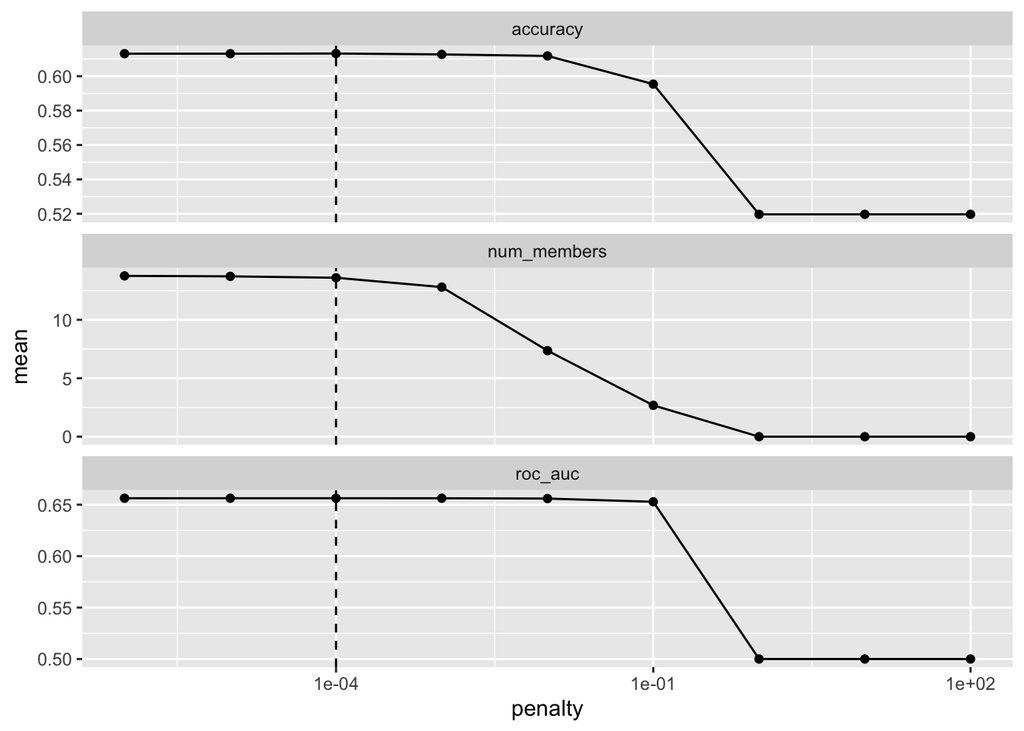

```r
autoplot(model_st)
```

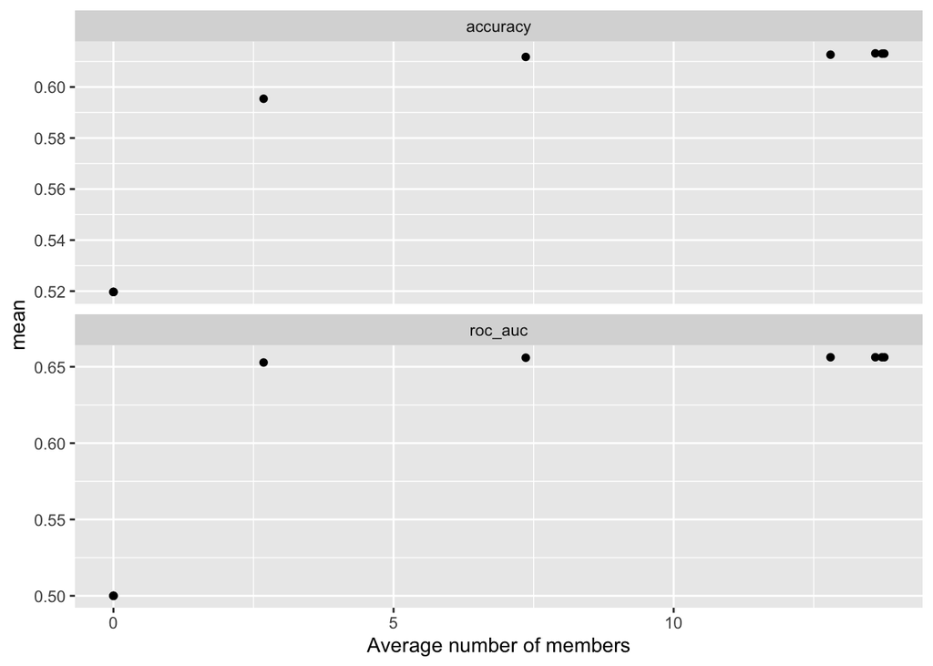

```r
autoplot(model_st, type = "members")
```

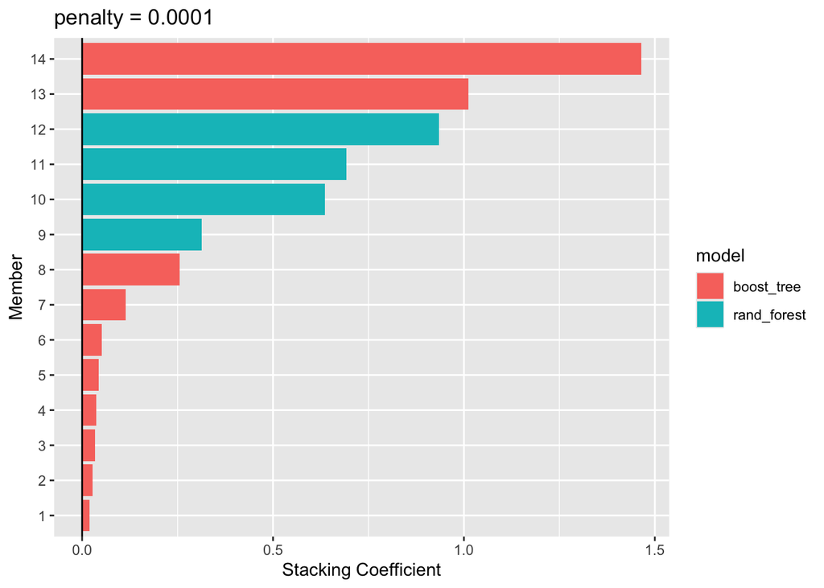

```r
autoplot(model_st, type = "weights")
```

```r
collect_parameters(model_st, "rf_fit")
```

```
# A tibble: 15 × 5
   member       mtry trees terms                    coef
   <chr>       <int> <int> <chr>                   <dbl>
 1 rf_fit_1_01     2   500 .pred_short_rf_fit_1_01 0
 2 rf_fit_1_02     2   600 .pred_short_rf_fit_1_02 0
 3 rf_fit_1_03     2   700 .pred_short_rf_fit_1_03 0.314
 4 rf_fit_1_04     3   500 .pred_short_rf_fit_1_04 0.635
 5 rf_fit_1_05     3   600 .pred_short_rf_fit_1_05 0.935
 6 rf_fit_1_06     3   700 .pred_short_rf_fit_1_06 0
 7 rf_fit_1_07     4   500 .pred_short_rf_fit_1_07 0.692
 8 rf_fit_1_08     4   600 .pred_short_rf_fit_1_08 0
 9 rf_fit_1_09     4   700 .pred_short_rf_fit_1_09 0
10 rf_fit_1_10     5   500 .pred_short_rf_fit_1_10 0
11 rf_fit_1_11     5   600 .pred_short_rf_fit_1_11 0
12 rf_fit_1_12     5   700 .pred_short_rf_fit_1_12 0
13 rf_fit_1_13     7   500 .pred_short_rf_fit_1_13 0
14 rf_fit_1_14     7   600 .pred_short_rf_fit_1_14 0
15 rf_fit_1_15     7   700 .pred_short_rf_fit_1_15 0
```

# 4. Compare model classification performance on the test set.

Report both the area under ROC curve and accuracy for each machine learning algorithm and the model stacking. Interpret the results. What are the most important features in predicting long ICU stays? How do the models compare in terms of performance and interpretability?

## Logistic regression

```r
# Final workflow
lr_final_wf <- lr_wf |>
  finalize_workflow(best_logit)
lr_final_wf
```

```
══ Workflow ════════════════════════════════════════════════════════════════════
Preprocessor: Recipe
Model: logistic_reg()

── Preprocessor ────────────────────────────────────────────────────────────────
5 Recipe Steps

• step_impute_mean()
• step_impute_knn()
• step_dummy()
• step_zv()
• step_normalize()

── Model ───────────────────────────────────────────────────────────────────────
Logistic Regression Model Specification (classification)

Main Arguments:
  penalty = 0.000151991108295293
  mixture = 1

Computational engine: glmnet
```

```r
# Fit the whole training set, then predict the test cases
lr_final_fit <-
  lr_final_wf |>
  last_fit(data_split)
lr_final_fit
```

```
# Resampling results
# Manual resampling
# A tibble: 1 × 6
  splits                id             .metrics .notes   .predictions .workflow
  <list>                <chr>          <list>   <list>   <list>       <list>
1 <split [36590/36591]> train/test sp… <tibble> <tibble> <tibble>     <workflow>
```

```r
# Test metrics
lr_final_fit |>
  collect_metrics()
```

```
# A tibble: 2 × 4
  .metric  .estimator .estimate .config
  <chr>    <chr>          <dbl> <chr>
1 accuracy binary         0.579 Preprocessor1_Model1
2 roc_auc  binary         0.610 Preprocessor1_Model1
```

```r
final_tree_lr <- extract_workflow(lr_final_fit)
final_tree_lr
```

```
══ Workflow [trained] ══════════════════════════════════════════════════════════
Preprocessor: Recipe
Model: logistic_reg()

── Preprocessor ────────────────────────────────────────────────────────────────
5 Recipe Steps

• step_impute_mean()
• step_impute_knn()
• step_dummy()
• step_zv()
• step_normalize()

── Model ───────────────────────────────────────────────────────────────────────

```

[output cut: 52 more lines]

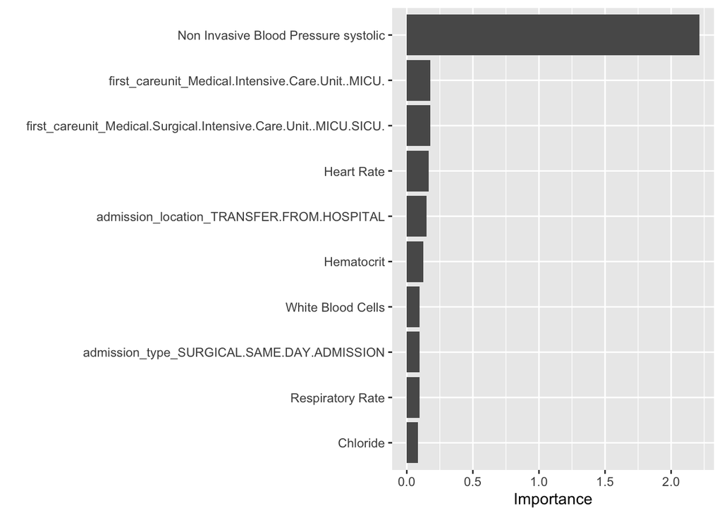

```r
final_tree_lr %>%
  extract_fit_parsnip() %>%
  vip()
```

## Random forest

```r
# Final workflow
rf_final_wf <- rf_wf %>%
  finalize_workflow(best_rf)
rf_final_wf
```

```
══ Workflow ════════════════════════════════════════════════════════════════════
Preprocessor: Recipe
Model: rand_forest()

── Preprocessor ────────────────────────────────────────────────────────────────
5 Recipe Steps

• step_impute_mean()
• step_impute_knn()
• step_dummy()
• step_zv()
• step_normalize()

── Model ───────────────────────────────────────────────────────────────────────
Random Forest Model Specification (classification)

Main Arguments:
  mtry = 3
  trees = 600

Engine-Specific Arguments:
  importance = impurity

Computational engine: ranger
```

```r
# Fit the whole training set, then predict the test cases
rf_final_fit <-
  rf_final_wf %>%
  last_fit(data_split)
rf_final_fit
```

```
# Resampling results
# Manual resampling
# A tibble: 1 × 6
  splits                id             .metrics .notes   .predictions .workflow
  <list>                <chr>          <list>   <list>   <list>       <list>
1 <split [36590/36591]> train/test sp… <tibble> <tibble> <tibble>     <workflow>
```

```r
# Test metrics
rf_final_fit %>%
  collect_metrics()
```

```
# A tibble: 2 × 4
  .metric  .estimator .estimate .config
  <chr>    <chr>          <dbl> <chr>
1 accuracy binary         0.605 Preprocessor1_Model1
2 roc_auc  binary         0.644 Preprocessor1_Model1
```

```r
final_tree_rf <- extract_workflow(rf_final_fit)
final_tree_rf
```

```
══ Workflow [trained] ══════════════════════════════════════════════════════════
Preprocessor: Recipe
Model: rand_forest()

── Preprocessor ────────────────────────────────────────────────────────────────
5 Recipe Steps

• step_impute_mean()
• step_impute_knn()
• step_dummy()
• step_zv()
• step_normalize()

── Model ───────────────────────────────────────────────────────────────────────
Ranger result

Call:
 ranger::ranger(x = maybe_data_frame(x), y = y, mtry = min_cols(~3L,      x), num.trees = ~600L, importance = ~"impurity", num.threads = 1,      verbose = FALSE, seed = sample.int(10^5, 1), probability = TRUE)

Type:                             Probability estimation
Number of trees:                  600
Sample size:                      36590
Number of independent variables:  39
Mtry:                             3
Target node size:                 10
Variable importance mode:         impurity
Splitrule:                        gini
OOB prediction error (Brier s.):  0.2349321
```

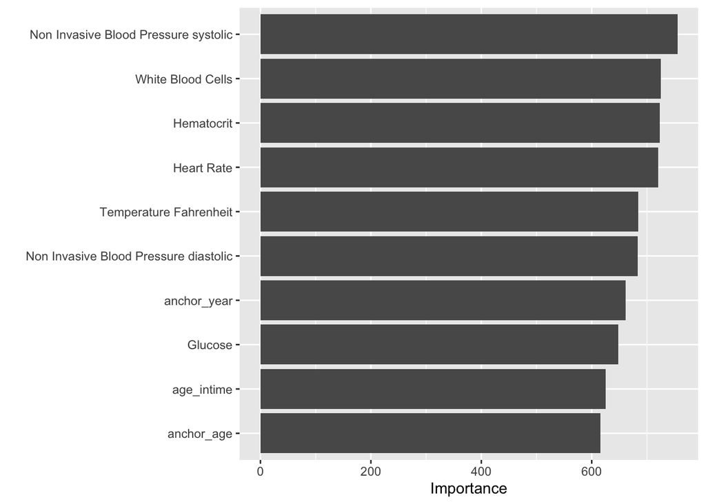

```r
final_tree_rf %>%
  extract_fit_parsnip() %>%
  vip()
```

## Boosting

```r
# Final workflow
gb_final_wf <- gb_wf %>%
  finalize_workflow(best_gb)
gb_final_wf
```

```
══ Workflow ════════════════════════════════════════════════════════════════════
Preprocessor: Recipe
Model: boost_tree()

── Preprocessor ────────────────────────────────────────────────────────────────
5 Recipe Steps

• step_impute_mean()
• step_impute_knn()
• step_dummy()
• step_zv()
• step_normalize()

── Model ───────────────────────────────────────────────────────────────────────
Boosted Tree Model Specification (classification)

Main Arguments:
  trees = 1000
  tree_depth = 3
  learn_rate = 0.0774263682681127

Computational engine: xgboost
```

```r
# Fit the whole training set, then predict the test cases
gb_final_fit <-
  gb_final_wf %>%
  last_fit(data_split)
gb_final_fit
```

```
# Resampling results
# Manual resampling
# A tibble: 1 × 6
  splits                id             .metrics .notes   .predictions .workflow
  <list>                <chr>          <list>   <list>   <list>       <list>
1 <split [36590/36591]> train/test sp… <tibble> <tibble> <tibble>     <workflow>
```

```r
# Test metrics
gb_final_fit %>%
  collect_metrics()
```

```
# A tibble: 2 × 4
  .metric  .estimator .estimate .config
  <chr>    <chr>          <dbl> <chr>
1 accuracy binary         0.606 Preprocessor1_Model1
2 roc_auc  binary         0.647 Preprocessor1_Model1
```

```r
final_tree_gb <- extract_workflow(gb_final_fit)
final_tree_gb
```

```
══ Workflow [trained] ══════════════════════════════════════════════════════════
Preprocessor: Recipe
Model: boost_tree()

── Preprocessor ────────────────────────────────────────────────────────────────
5 Recipe Steps

• step_impute_mean()
• step_impute_knn()
• step_dummy()
• step_zv()
• step_normalize()

── Model ───────────────────────────────────────────────────────────────────────
##### xgb.Booster
raw: 1.1 Mb
call:
  xgboost::xgb.train(params = list(eta = 0.0774263682681127, max_depth = 3L,
    gamma = 0, colsample_bytree = 1, colsample_bynode = 1, min_child_weight = 1,
    subsample = 1), data = x$data, nrounds = 1000, watchlist = x$watchlist,
    verbose = 0, nthread = 1, objective = "binary:logistic")
params (as set within xgb.train):
  eta = "0.0774263682681127", max_depth = "3", gamma = "0", colsample_bytree = "1", colsample_bynode = "1", min_child_weight = "1", subsample = "1", nthread = "1", objective = "binary:logistic", validate_parameters = "TRUE"
xgb.attributes:
  niter
callbacks:
  cb.evaluation.log()
# of features: 39
niter: 1000
nfeatures : 39
evaluation_log:
     iter training_logloss
    <num>            <num>
        1        0.6914320
        2        0.6899615
---
      999        0.6018867
     1000        0.6018532
```

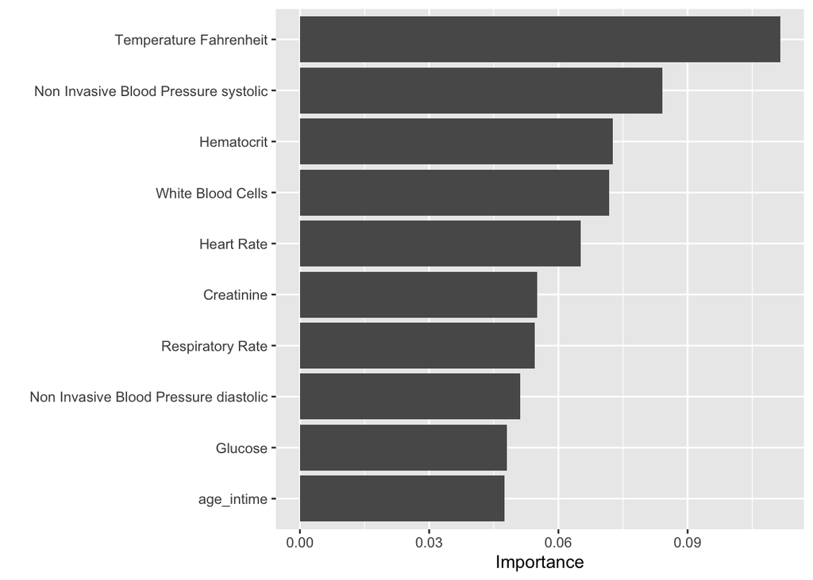

```r
final_tree_gb %>%
  extract_fit_parsnip() %>%
  vip()
```

MLP

```r
# mlp_final_wf <- mlp_wf |>
#   finalize_workflow(best_mlp)
# mlp_final_wf
```

```r
# mlp_final_fit <-
#   mlp_final_wf |>
#   last_fit(data_split)
# mlp_final_fit
```

```r
# mlp_final_fit |>
#   collect_metrics()
```

## Stacking

```r
mimic_pred <- mimic_test %>%
  bind_cols(predict(model_st, ., type = "class")) %>%
  print(width = Inf)
```

```
# A tibble: 36,591 × 26
   first_careunit                                   admission_type
   <fct>                                            <fct>
 1 Medical Intensive Care Unit (MICU)               EW EMER.
 2 Medical Intensive Care Unit (MICU)               OBSERVATION ADMIT
 3 Medical Intensive Care Unit (MICU)               EW EMER.
 4 Medical/Surgical Intensive Care Unit (MICU/SICU) EW EMER.
 5 Other                                            OBSERVATION ADMIT
 6 Medical Intensive Care Unit (MICU)               EW EMER.
 7 Surgical Intensive Care Unit (SICU)              EW EMER.
 8 Other                                            URGENT
 9 Cardiac Vascular Intensive Care Unit (CVICU)     SURGICAL SAME DAY ADMISSION
10 Medical Intensive Care Unit (MICU)               EW EMER.
   admission_location     insurance language marital_status race  gender
   <fct>                  <fct>     <fct>    <fct>          <fct> <fct>
```

[output cut: 71 more lines]

Computing the accuracy for the model:

```r
acc_res <- accuracy(data = mimic_pred, truth = los_long, .pred_class)
print(acc_res)
```

```
# A tibble: 1 × 3
  .metric  .estimator .estimate
  <chr>    <chr>          <dbl>
1 accuracy binary         0.610
```

Compute AUC for the model

```r
mimic_pred_auc <- mimic_test %>%
  bind_cols(predict(model_st, ., type = "prob")) %>%
  print(width = Inf)
```

```
# A tibble: 36,591 × 27
   first_careunit                                   admission_type
   <fct>                                            <fct>
 1 Medical Intensive Care Unit (MICU)               EW EMER.
 2 Medical Intensive Care Unit (MICU)               OBSERVATION ADMIT
 3 Medical Intensive Care Unit (MICU)               EW EMER.
 4 Medical/Surgical Intensive Care Unit (MICU/SICU) EW EMER.
 5 Other                                            OBSERVATION ADMIT
 6 Medical Intensive Care Unit (MICU)               EW EMER.
 7 Surgical Intensive Care Unit (SICU)              EW EMER.
 8 Other                                            URGENT
 9 Cardiac Vascular Intensive Care Unit (CVICU)     SURGICAL SAME DAY ADMISSION
10 Medical Intensive Care Unit (MICU)               EW EMER.
   admission_location     insurance language marital_status race  gender
   <fct>                  <fct>     <fct>    <fct>          <fct> <fct>
```

[output cut: 71 more lines]

```r
roc_auc_res <- roc_auc(data = mimic_pred_auc, truth = los_long, .pred_long)
print(roc_auc_res)
```

```
# A tibble: 1 × 3
  .metric .estimator .estimate
  <chr>   <chr>          <dbl>
1 roc_auc binary         0.653
```

We can use the members argument to generate predictions from each of the ensemble members.

```r
mimic_pred <-
  mimic_test |>
  select(los_long) |>
  bind_cols(
    predict(
      model_st,
      mimic_test,
      type = "class",
      members = TRUE
    )
  ) |>
  print(width = Inf)
```

```
# A tibble: 36,591 × 16
   los_long .pred_class .pred_class_rf_fit_1_03 .pred_class_rf_fit_1_04
   <fct>    <fct>       <fct>                   <fct>
 1 short    short       short                   short
 2 long     short       short                   long
 3 short    long        long                    long
 4 long     short       short                   short
 5 long     short       short                   short
 6 long     long        long                    long
 7 long     long        long                    long
 8 long     long        long                    long
 9 short    short       short                   short
10 short    short       short                   short
   .pred_class_rf_fit_1_05 .pred_class_rf_fit_1_07 .pred_class_gb_fit_1_19
   <fct>                   <fct>                   <fct>
```

[output cut: 47 more lines]

```r
map(
  colnames(mimic_pred),
  ~ mean(mimic_pred$los_long == pull(mimic_pred, .x))
) |>
  set_names(colnames(mimic_pred)) |>
  as_tibble() |>
  pivot_longer(c(everything(), -los_long))
```

```
# A tibble: 15 × 3
   los_long name                    value
      <dbl> <chr>                   <dbl>
 1        1 .pred_class             0.610
 2        1 .pred_class_rf_fit_1_03 0.603
 3        1 .pred_class_rf_fit_1_04 0.603
 4        1 .pred_class_rf_fit_1_05 0.605
 5        1 .pred_class_rf_fit_1_07 0.604
 6        1 .pred_class_gb_fit_1_19 0.600
 7        1 .pred_class_gb_fit_1_28 0.551
 8        1 .pred_class_gb_fit_1_17 0.606
 9        1 .pred_class_gb_fit_1_20 0.599
10        1 .pred_class_gb_fit_1_23 0.549
11        1 .pred_class_gb_fit_1_26 0.440
12        1 .pred_class_gb_fit_1_18 0.606
13        1 .pred_class_gb_fit_1_21 0.586
14        1 .pred_class_gb_fit_1_24 0.520
15        1 .pred_class_gb_fit_1_27 0.479
```

# Performance Evaluation

Since running SVM and MLP will cause a huge time to render, here we abandon these two models due to time efficiency. From above results of logistic model, random forest model, boosting model, and stacking model, we can have this table to report the results of accuracy and AUC:

| Model | Accuracy | AUC |
| --- | --- | --- |
| Logistic | 0.5788035 | 0.6098944 |
| Random Forest | 0.6046296 | 0.6443734 |
| Boosting | 0.6059414 | 0.6471571 |
| Stacking | 0.6097948 | 0.6526687 |

Here we can see random forest, boosting, and stacking models have a obvious better performance than logistic model, as logistic model is like a baseline model here.

From the variable importance plot, we can see that important features are those observations in lab events and chart events, especially for Non Invasive Blood Pressure systolic. It is following our commonsense since Non Invasive Blood Pressure systolic is most directly related to patients’ health condition in clinical trial. The significance of these lab data and chart data also follows our commonsense since these data can directly reflect the health condition of patients.

From the table, we can see that stack model is a little bit better than random forest and boosting on performance of accuracy and AUC. However, stack model will lose its interpretability, as it is a combination of random forest and boosting models. We cannot interpret which feature is more significant in predicting long ICU stays.

When performances of models are close, we will prefer the simplier model in order to have a better interpretability. Therefore, with a trade-off between performance and interpretability, we will prefer to lose a little bit performance to choose random forest model or boosting model as the best model to predict long ICU stays since it has the best balance of performance and interpretability.